# Homework 6

PSTAT 231

Anna Kazachka

May 24, 2022

## Tree-Based Models

### Exercise 1

Read in the data and set things up as in Homework 5:

- Use `clean_names()`
- Filter out the rarer Pokémon types
- Convert `type_1` and `legendary` to factors

```r
setwd("/Users/annakazachka/231")
pokemon <- read_csv("Pokemon.csv")
library(janitor)
pokemon <- clean_names(pokemon)
pokemon <- pokemon[pokemon$type_1 %in% c("Bug", "Fire", "Grass", "Normal", "Water", "Psychic"),]
pokemon$type_1 <- as.factor(pokemon$type_1)
pokemon$legendary <- as.factor(pokemon$legendary)

pokemon
```

```
## # A tibble: 458 × 13
##    number name      type_1 type_2 total    hp attack defense sp_atk sp_def speed
##     <dbl> <chr>     <fct>  <chr>  <dbl> <dbl>  <dbl>   <dbl>  <dbl>  <dbl> <dbl>
##  1      1 Bulbasaur Grass  Poison   318    45     49      49     65     65    45
##  2      2 Ivysaur   Grass  Poison   405    60     62      63     80     80    60
##  3      3 Venusaur  Grass  Poison   525    80     82      83    100    100    80
##  4      3 Venusaur… Grass  Poison   625    80    100     123    122    120    80
##  5      4 Charmand… Fire   <NA>     309    39     52      43     60     50    65
##  6      5 Charmele… Fire   <NA>     405    58     64      58     80     65    80
##  7      6 Charizard Fire   Flying   534    78     84      78    109     85   100
##  8      6 Charizar… Fire   Dragon   634    78    130     111    130     85   100
##  9      6 Charizar… Fire   Flying   634    78    104      78    159    115   100
## 10      7 Squirtle  Water  <NA>     314    44     48      65     50     64    43
## # … with 448 more rows, and 2 more variables: generation <dbl>, legendary <fct>
```

Do an initial split of the data; you can choose the percentage for splitting. Stratify on the outcome variable.

```r
set.seed(777)
pokemon_split <- initial_split(pokemon, strata = "type_1", prop = 0.80)
pokemon_train <- training(pokemon_split)
pokemon_test <- testing(pokemon_split)
```

Fold the training set using *v*-fold cross-validation, with `v = 5`. Stratify on the outcome variable.

```r
pokemon_fold <- vfold_cv(pokemon, v = 5, strata = "type_1")
```

Set up a recipe to predict `type_1` with `legendary`, `generation`, `sp_atk`, `attack`, `speed`, `defense`, `hp`, and `sp_def`:

- Dummy-code `legendary` and `generation`;
- Center and scale all predictors.

```r
pokemon_recipe <- recipe(type_1 ~ legendary + generation + sp_atk + attack + speed + defense + hp + sp_def, pokemon_train) %>%
  step_dummy(all_nominal_predictors()) %>%
  step_center(all_predictors()) %>%
  step_scale(all_predictors())
```

### Exercise 2

Create a correlation matrix of the training set, using the `corrplot` package. *Note: You can choose how to handle the continuous variables for this plot; justify your decision(s).*

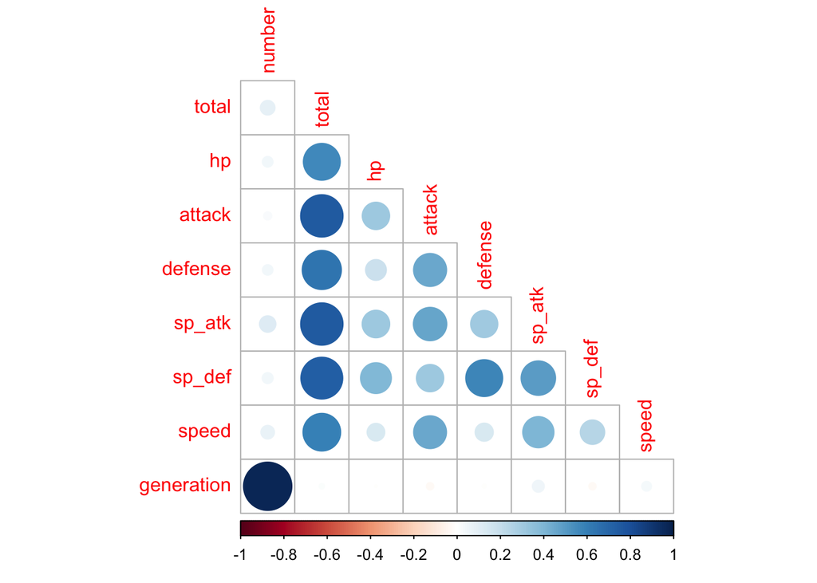

```r
pokemon_train %>%
  select(is.numeric) %>%
  cor(use = "complete.obs") %>%
  corrplot(type = "lower", diag = FALSE)
```

What relationships, if any, do you notice? Do these relationships make sense to you?

There is strong positive correlation between generation and number. Yes because relationships like having “good” attack means there should be “good” speed.

### Exercise 3

First, set up a decision tree model and workflow. Tune the `cost_complexity` hyperparameter. Use the same levels we used in Lab 7 – that is, `range = c(-3, -1)`. Specify that the metric we want to optimize is `roc_auc`.

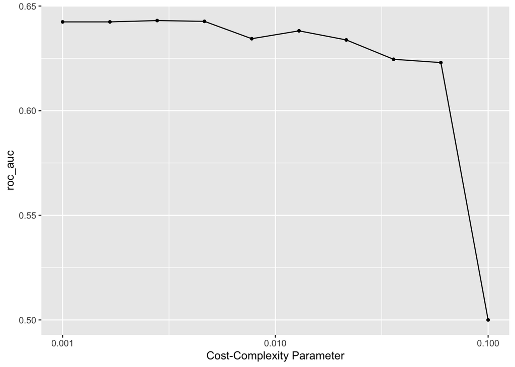

```r
tree_spec <- decision_tree() %>%
  set_engine("rpart")
class_tree_spec <- tree_spec %>%
  set_mode("classification")
class_tree_wf <- workflow() %>%
  add_model(class_tree_spec %>% set_args(cost_complexity = tune())) %>%
  add_recipe(pokemon_recipe)
param_grid <- grid_regular(cost_complexity(range = c(-3, -1)), levels = 10)
tune_res <- tune_grid(
  class_tree_wf,
  resamples = pokemon_fold,
  grid = param_grid,
  metrics = metric_set(roc_auc))
autoplot(tune_res)
```

Print an `autoplot()` of the results. What do you observe? Does a single decision tree perform better with a smaller or larger complexity penalty?

A single decision tree performs better with a smaller complexity penalty. Sharp decrease in roc auc after around 0.08 cost-complexity.

### Exercise 4

What is the `roc_auc` of your best-performing pruned decision tree on the folds? *Hint: Use `collect_metrics()` and `arrange()`.*

```r
arrange(collect_metrics(tune_res), desc(mean))
```

```
## # A tibble: 10 × 7
##    cost_complexity .metric .estimator  mean     n std_err .config
##              <dbl> <chr>   <chr>      <dbl> <int>   <dbl> <chr>
##  1         0.00278 roc_auc hand_till  0.643     5  0.0202 Preprocessor1_Model03
##  2         0.00464 roc_auc hand_till  0.643     5  0.0204 Preprocessor1_Model04
##  3         0.001   roc_auc hand_till  0.642     5  0.0200 Preprocessor1_Model01
##  4         0.00167 roc_auc hand_till  0.642     5  0.0200 Preprocessor1_Model02
##  5         0.0129  roc_auc hand_till  0.638     5  0.0256 Preprocessor1_Model06
##  6         0.00774 roc_auc hand_till  0.634     5  0.0208 Preprocessor1_Model05
##  7         0.0215  roc_auc hand_till  0.634     5  0.0197 Preprocessor1_Model07
##  8         0.0359  roc_auc hand_till  0.625     5  0.0210 Preprocessor1_Model08
##  9         0.0599  roc_auc hand_till  0.623     5  0.0175 Preprocessor1_Model09
## 10         0.1     roc_auc hand_till  0.5       5  0      Preprocessor1_Model10
```

```r
select_best(tune_res)
```

```
## # A tibble: 1 × 2
##   cost_complexity .config
##             <dbl> <chr>
## 1         0.00278 Preprocessor1_Model03
```

```r
#0.6430640
```

### Exercise 5

Using `rpart.plot`, fit and visualize your best-performing pruned decision tree with the *training* set.

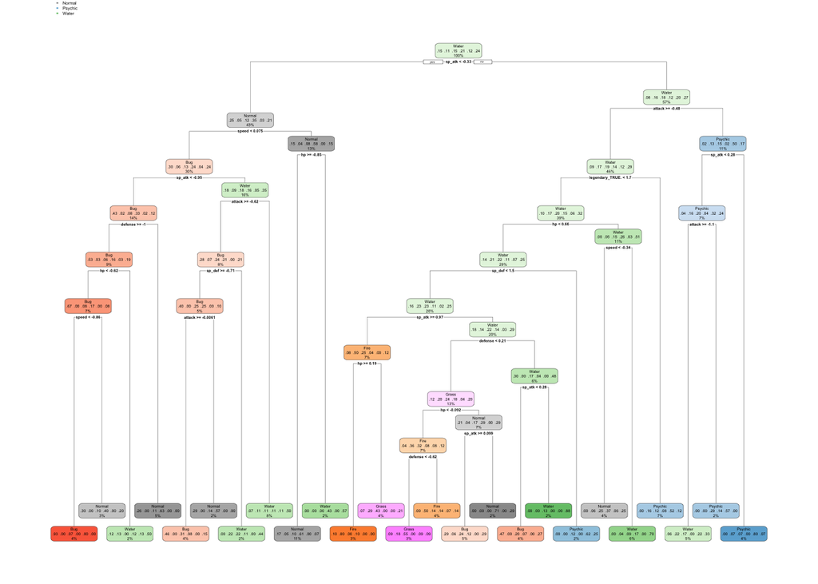

```r
best_complexity <- select_best(tune_res)
class_tree_final <- finalize_workflow(class_tree_wf, best_complexity)
class_tree_final_fit <- fit(class_tree_final, data = pokemon_train)
class_tree_final_fit %>%
  extract_fit_engine() %>%
  rpart.plot(roundint=FALSE)
```

### Exercise 5

Now set up a random forest model and workflow. Use the `ranger` engine and set `importance = "impurity"`. Tune `mtry`, `trees`, and `min_n`. Using the documentation for `rand_forest()`, explain in your own words what each of these hyperparameters represent.

```r
random_spec <- rand_forest() %>%
  set_engine("ranger", importance = "impurity") %>%
  set_mode("classification")
random_wf <- workflow() %>%
  add_model(random_spec %>% set_args(mtry = tune(), trees = tune(), min_n = tune())) %>%
  add_recipe(pokemon_recipe)
```

The hyperparameters represent (mtry) number of variables to split at each node, (trees) number of trees, (min_n) minimum node size.

Create a regular grid with 8 levels each. You can choose plausible ranges for each hyperparameter. Note that `mtry` should not be smaller than 1 or larger than 8. **Explain why not. What type of model would `mtry = 8` represent?**

```r
random_grid <- grid_regular(mtry(range = c(1,8)), trees(range = c(1, 6)), min_n(range = c(2,10)), levels = 8)
```

‘mtry’ should not be smaller than 1 or larger than 8 because there are only 8 predictors.

### Exercise 6

Specify `roc_auc` as a metric. Tune the model and print an `autoplot()` of the results. What do you observe? What values of the hyperparameters seem to yield the best performance?

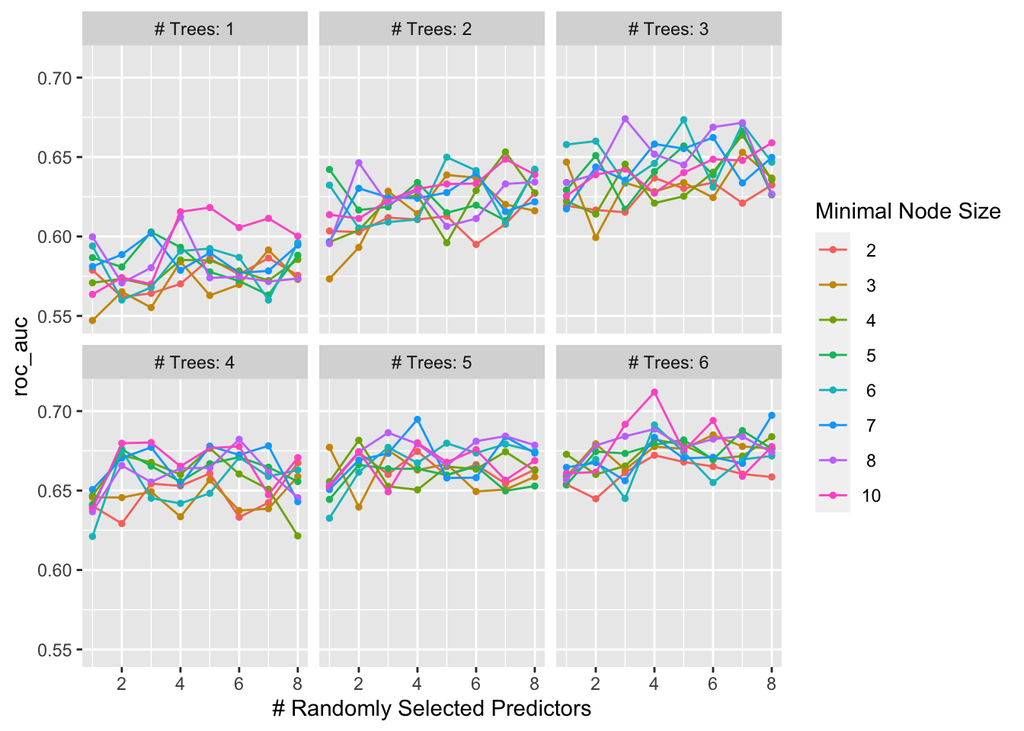

```r
tune_random <- tune_grid(
  random_wf,
  resamples = pokemon_fold,
  grid = random_grid,
  metrics = metric_set(roc_auc))
autoplot(tune_random)
```